# Develop pilferage function

Vera Vinken

## Packages

```r
library(dplyr)        # For summarizing means across groups
library(SciViews)     # For the easy to use ln() function
```

## Background

We decided to put pilferage in the model. No large effect is expected, but because other models in literature (Pravosudov & Lucas (2001)) use it, we will implement this as well. The halflife used is that of 20 days, which was observed by Brodin in 1994 and described in his paper from that year. The function should do the following:

- Determine the decay constant (this will be set throughout simulatiosn as the halflife is set)
- Determine a probabilty that within 1 timestep 1 or more items will decay.
- Then compare this to a randomly generated number between 0 and 1
- If our probability is larger than this number, an item will decay (we assume just 1, as the probability that this is 2 or more is incredibly small)
- cache number needs to be updated accordingly

## Exploring the basic functionality

Here I use the maths as they are used for radioactive decay curves. https://www.britannica.com/science/decay-constant. I have made a small model that simulates a number of `days` where birds start of with a number of caches (`num_cach_start`). The number of birds (`num_birds`) can be inputted as well.

$P_{oneOrMore} = 1 - P_{noDecay}$

and

$P_{noDecay} = e^{-lambda}$

and

$lambda = ln(2)/T_{halflife}$

```r
# Number of days to simulate
days<-90
# Number of caches to start with
num_cach_start<-100
# How to often do we repeat this, and take an average at the end
num_birds<-100
# start for loop
for (j in 1:num_birds){
  if (j==1){
    repeats_list<-list()}
  # Start loop trough timesteps
          ts<-days*72
          for (i in 1:ts){
          if (i==1){
            samplesize<-num_cach_start
            number<-1:ts
            df<-as.data.frame(number)}
          df$samplesize[i]<-samplesize
          # Determine the decay constant
          # We take this from an exponential decay curve with a T-halflife of 1440 timesteps
          # This comes down to 20 days, as described in P & L (2001) and Brodin 1994
          # Formula: lambda = 0.693/T-halflife
          lambda<-(ln(2))/1440
          # Take the sample size into account
          lambda_2<-lambda*samplesize
          # To find out the probability that k items out of x number of caches have decayed after 1 timestep
          # CAlcualte this probability for different values of k and then sum them up to find the total probability of any number of items decaying
          # To find out the expected umber of items that decayed, calculated teh mean (lambda) of a poisson distribution
          # Using complement probability
          # P(at least one item decays) = 1 - (P (X = 0))
          # With P(X=0) the probability that no items decay
          # So first calculate the P(X=0) with k= 0 (0 items decayed )
          # P(X=0)= ((e^-lambda) * (lambda^0))/0! = e^(-lambda)
          # We know lambda so we can easily calcualte P(X=0)
          P_noDecay<-exp(-lambda_2)
          df$P_noDecay[i]<-P_noDecay
          # Now calcualte the chance that 1 or more items decayed
          P_oneOrMore<-(1-P_noDecay)
          df$P_oneOrMore[i]<-P_oneOrMore
          # Pull a random number
          P_random<-runif(1)
          df$random[i]<-P_random
          # Check
          if(P_oneOrMore>P_random){
            df$singleDecay[i]<-1
            samplesize<-samplesize-1
            # make sure it doesnt go below 0
            if(samplesize<0){
              samplesize<-0
            }
          }else{
          df$singleDecay[i]<-0 }  }
          df$num_rep<-j
        # Put the dataframe in the list
          repeats_list[[j]]<-df
} # end the j for loop
# bind together
total_df<-do.call('rbind', repeats_list)
# aggregate means
mean_df<-total_df%>%
  group_by(number) %>%
  summarise(mean_samplesize=mean(samplesize))
```

The output can be plotted as follows. Below is the result of a simulation of 100 birds, for 90 days that each start with 100 caches. The green horizontal line shows the starting number of caches. Red vertical lines indicate 1 halflife time to be passed (20 days). The top horizontal line indicates half of the initial caches. The second horizontal life indicates 1/4 of the initial caches, etc. Check with Tom if he’s happy with this.

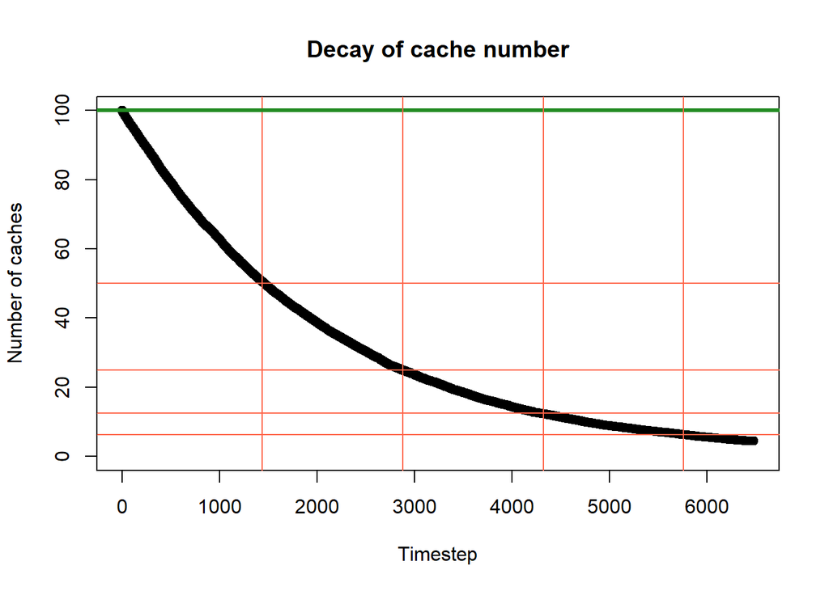

Now I need to build a function that can fit into our larger model and test it.

```r
# Half life should be set in the general set up
cache_halflife<-20*72                             # 15/09/2023: Included in gen setup function
# Same for lambda
lambda<-(ln(2))/cache_halflife                    # 15/09/2023: Included in gen setup function
# The two matrices need to be initiated in the individual setup ( I think, just check where the predation matrices are)
# Here are some dummy ones
mat_Pdecay<-matrix(NA,1,20)                       # 15/09/2023: Included in indiv-setup function
decay_count<-matrix(NA, 1,20)                     # 15/09/2023: Included in indiv-setup function
mat_caches<-matrix(c(NA), 1, 20)
mat_caches[1,1]<-0

# write function
pilf_func<-function(i,t, lambda){
  # Calculcate the current lambda for all caches that this bird has
  cur_lambda<<-(lambda*mat_caches[i,t])
  # calculate the probability of no decay at all
  P_noDecay<<-exp(-cur_lambda)
  # Now calculate the chance that 1 or more caches decayed
  P_oneOrMore<<-(1-P_noDecay)
  # add that to the matrix
  mat_Pdecay[i,t]<<-P_oneOrMore
  # Set a random nuber
  P_random<<-runif(1)

  if(P_oneOrMore>P_random){
    # pilfer 1 item
    mat_caches[i,t]<<-(mat_caches[i,t]-1)
    if(mat_caches[i,t]<0){
      mat_caches[i,t]<<-0
    }
    # set the counting matrix
    decay_count[i,t]<<-1
  }else{
    decay_count[i,t]<<-0
  }
}


# To test the function write a little loop around it

for (k in 1:20){

pilf_func(i=1,t=k, lambda)

  if(k==20){
    print('done')
  }else{
  # need to artificially move the cache number to the next timestep
  mat_caches[,(k+1)]<-mat_caches[,k]
  print(paste(k, 'done'))
  }

}
```

[output not shown]

It looks like the function works well. Now I need to include it in the existing code, with the following steps.

- set `cache_halflife` and `lambda` in the general setup function. **Done**.
- initiate the `mat_Pdecay` and `decay_count` matrices in the individual setup function. Done.
- Add the `pilf_func` to the `FuncSource` file. **Done**.
- Plug the `pilf_func` into model 11: This should be at the end of each timestep, just before the wrapup. Would be good to include an if-statement that checks if there are actually caches. If not, this doesn’t need to run. **Done**.
- Consider in which way the matrices of this need to be used? Am I interested in those at all? I’ve added the `count_decay` to the saved matrices. I don’t think we’re interested in the `PoneOrMore` for the long run. All I did was add ‘decay_count’ to the list at the end of the model and then change the number of variables in the `create_df_func`Check if Tom is happy.
- Check that the `ts_prep_func` correctly transfers the number of caches to the next timestep. **Done**.
- Check if `retrieval_func` cannot cause caches to go lower than 0. **Done**.
- Test 11 singular run **Done**.
- Test 11 environment parallel run: I had to add the `SciViews` package to the `foreach %dopar%` loop –> will need to happen for all of them. **Done**.

The following models are updated (changes made + single local run + environment local run):

- model 1.1
- model 1.2
- model 1.3.1
- model 1.3.2

Once the local stuff all works, I’ll need to optimize everything again. For this:

- Update the HPC scripts (curently ony for the 3 threshold models): add the ln() pacackage, read through code to see if anything needs changing. Apart from the R shell, it should pull directly from the updated Sourcefiles
- Run on HPC
- Repeat for all other models

Next I want to get 1.3.1 running on the HPC so I can start putting jobs through.This needs to wait till I’ve checked any final model changes with Tom.